# ReSCUE Seabird Flight Height Toolkit User Guide

Black Bawks Data Science, DMP Statistics and NIRAS

26 August 2026

**Applies to:** ReSCUEApp v0.9.1  
**Guide version:** 1.0 (draft, Phase 1 prototype)  
**Live version:** https://uat-pub.marinedataexchange.co.uk/content/info/ReSCUE  
**ShinyApps.io:** https://dmpstats.shinyapps.io/ReSCUEApp/

> **This guide describes the Phase 1 prototype.** The application currently runs on **randomly generated placeholder data**. The distributions you see are not real and must not be used in any assessment. Some features are still in development; these are marked *Coming in the final release* throughout.

## About this guide

This guide is written for ecological practitioners — consultants, developers, SNCB advisors, eNGO and academic users — who need to obtain seabird flight height distributions for use in impact assessment. It assumes no knowledge of R or of the code behind the application.

If you prefer to learn by doing, the **Start Tutorial** button on the welcome screen runs a short guided tour of the main screens. This guide covers the same ground in more detail.

## Background

The **Reducing Seabird Collisions Using Evidence (ReSCUE)** project is a multi-year, multi-partner initiative led by Natural England and funded by The Crown Estate’s Offshore Wind Evidence and Change (OWEC) Programme. It addresses a long-standing gap in the evidence base: the lack of accurate, fit-for-purpose data on seabird flight heights, which underpins any robust assessment of collision risk with offshore wind turbines.

The project works towards three objectives:

1. **Validating flight height estimation methods** — particularly combined camera-LiDAR Digital Aerial Surveys (DAS), alongside laser rangefinders and bird-borne telemetry.
2. **Assembling existing and collecting new flight height data** that is fit for purpose for offshore wind impact assessment.
3. **Creating publicly available datasets and analytical tools** to inform guidance, recommendations and evidence-led consenting decisions.

This toolkit is the public-facing front end to the third of those objectives. It sits on top of the ReSCUEtools R package, developed by the British Trust for Ornithology, which provides the statistical models behind the distributions.

### What is a flight height distribution?

A **flight height distribution** (FHD) describes how likely a bird is to be flying at each height above sea level. A distribution might show, for example, that a species spends most of its flight time between 10 and 30 m, with progressively less time higher and lower.

Flight height distributions matter because the proportion of flight time spent within the rotor-swept zone of a turbine is a direct input to collision risk modelling. A better distribution means a better-founded estimate of risk — and a better basis for judging whether a mitigation measure, such as raising the air gap, is worth its cost.

Every distribution in this toolkit is presented with a measure of uncertainty. That uncertainty is not decoration: a distribution estimated from sparse data will show a wide band, and outputs derived from it should be treated accordingly.

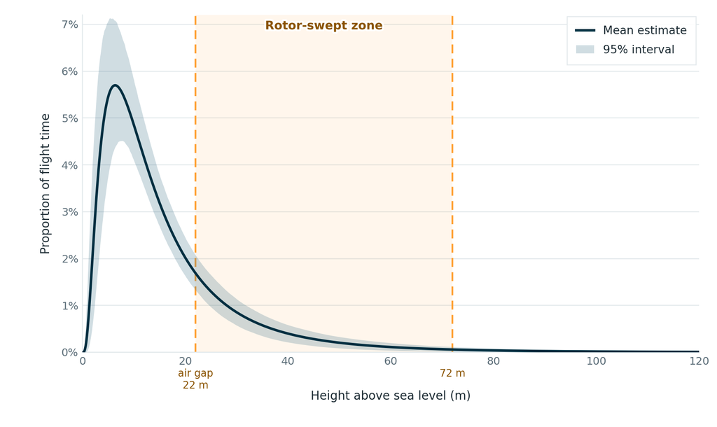

*Figure 1. An example flight height distribution, showing the mean estimate and its 95% interval, with a turbine rotor zone shaded.*

## What the toolkit does — and does not do

**It does:**

- give you access to the seabird flight height distributions produced by ReSCUE, filtered by species, sea area, survey method and season;
- let you compare several distributions side by side, including your own;
- let you explore how the proportion of flight time in the rotor zone changes as the air gap is raised or lowered;
- report summary statistics with their uncertainty.

**It does not:**

- perform collision risk modelling. Use the Stochastic Collision Risk Model (sCRM) or the Avian Migration Collision Risk Model (mCRM) for that. The toolkit is designed to produce outputs that feed into those tools.
- make a judgement about which distribution is appropriate for your assessment. It flags which distributions are recommended for use in collision risk modelling, but the choice, and its justification, remains yours.

## The welcome screen

Launching the application will land you on the welcome page, which will give a broad overview of the application, links to the project partners, contacts and the virtual tour / tutorial.

[figure not shown]

## Finding your way around

The application main screens can be reached from the icons in the navigation bar at the top right.

[figure not shown]

*Figure 3. The navigation bar.*

| Icon | Screen | What it is for |
| --- | --- | --- |
| House | **Welcome** | Project background, what the app does, contacts, the guided tour |
| Funnel | **Data Selection** | Find and select the distributions you want to work with |
| Bar chart | **Analysis** | Configure, compare and read your selected distributions |
| Book | **Documents** | Data Sources, this User Guide, and the Metadata Builder |
| Gear | **Settings** | Save or restore a session, report a bug, reset |

Two further controls sit in the navigation bar on the left:

- The **version number** — click it to see the release notes. If you report a problem, or need to record which version produced a result, this is the number to quote.
- The **GitHub icon** — links to the source code repository.

> **Look for the help icons.** Most panels carry a small **Help** button in their header. These open a short explanation of that panel without leaving the screen — useful when you want one specific answer rather than this whole document.

## Step 1 — Selecting flight height distributions

Open the **Data Selection** screen (funnel icon). The map on the left shows the areas for which distributions are available. Each shaded area is one or more distributions.

[figure not shown]

*Figure 4. The Data Selection screen.*

### Filtering

The controls beneath the map narrow what is shown:

| Filter | Behaviour |
| --- | --- |
| **Species** | One species at a time. A species is selected when you arrive. |
| **Method** | Choose one or more of LiDAR-DAS, GPS or Altimeter. Leave empty for all. |
| **Season** | Any, Both, Breeding or Non-breeding. |
| **Advanced Filters** | Opens two further filters: **Recommended for CRM?** and **Region**. |

An empty filter means “no constraint” — so leaving Method blank shows every method rather than none.

> **Start with Recommended for CRM.** If your purpose is a collision risk assessment, set **Advanced Filters → Recommended for CRM? → Yes** first.

### Choosing a distribution

Click any area on the map to open its details:

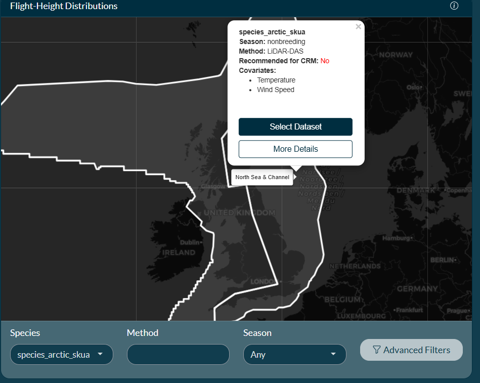

*Figure 5. A map popup, showing the summary and the two action buttons.*

The popup shows the species, season, method, whether the distribution is recommended for collision risk modelling (green **Yes** or red **No**), and any covariates it carries. Two buttons sit at the bottom:

- **Select Dataset** — adds it to your selection. The area turns orange and the button changes to *Deselect Dataset*.
- **More Details** — opens the full metadata record: spatial and temporal scale, year, region, site, species group and so on.

Selected distributions appear in the **Selected Flight-Height Distributions** table on the right. The bin icon in that panel clears the whole selection, including anything you have uploaded, after asking you to confirm.

> **You can select up to ten distributions.** Beyond ten the plot becomes unreadable and processing slows noticeably. If you select more, a warning appears and only the first ten are analysed.

When you are ready, click **Start Analysis**.

## Step 2 — Uploading your own distribution

If you hold a distribution the toolkit does not — for a species or area not yet covered, or from your own survey — you can bring it in. Click **Upload Data** on the Data Selection screen.

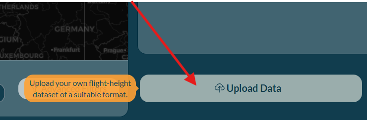

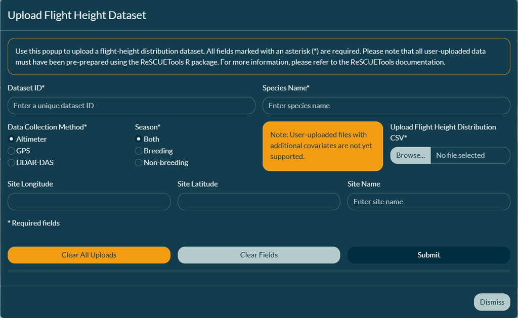

*Figure 6a/b. The upload dialogue.*

Your file must have been prepared with the **ReSCUEtools** R package. Complete the required fields, marked with an asterisk:

[output not shown]

Longitude, latitude and site name are optional. If you supply coordinates, your distribution appears on the map as a green circle alongside the ReSCUE areas, so you can see it in its geographic context.

Uploaded distributions are added to the selection table and can be compared with ReSCUE distributions in the same session. **Clear Fields** empties the form; **Clear All Uploads** removes every distribution you have uploaded.

> **Your data stays with you.** Uploaded files are held only for the length of your session and are never written to the server. Closing the browser discards them. There are no user accounts and no personal data is collected.

> *Coming in the final release:* uploads carrying covariates, and automatic checking of your file against the expected format. At present the file is accepted as supplied, so please check it yourself before relying on the output.

## Step 3 — Configuring and analysing

The **Analysis** screen has your selected distributions listed top-left, the analysis tables beneath, and the plot and export controls on the right.

[figure not shown]

*Figure 7. The Analysis screen.*

### The distribution list

Each selected distribution appears as a numbered row showing its common name and its method and season. The number is used to label that distribution in the plot legend. Two buttons sit on each row:

- **Details** — the full metadata record.
- **Configure** — covariate options, described below.

### Setting the rotor zone

Click **Turbine Parameters**, above the analysis tabs, and set:

- **Minimum Rotor Height (m)** — the air gap, i.e. the lowest point of the rotor-swept area. Default 50 m.
- **Maximum Rotor Height (m)** — the highest point. Default 70 m.

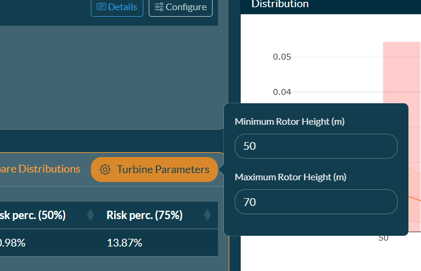

*Figure 8. The Turbine Parameters control.*

Everything on this screen — the summary statistics, the risk height table and the shaded band on the plot — responds to these two values. Set them to match the turbine you are assessing before reading anything else.

### Covariates

Some distributions are fitted with covariates, such as wind speed or temperature. Click **Configure** on a distribution to see them.

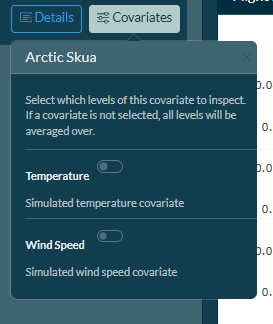

*Figure 9. The covariate configuration panel.*

Each covariate has a switch. Leave it **off** and the covariate is marginalised out across all its levels. Switch it **on** and you can choose which levels to show, and the distribution is split accordingly — one curve per level. You can switch any combination on and off: covariates are handled independently, so using one and ignoring another within the same distribution is fine.

Two points matter here:

> **Switching a covariate off does not narrow the distribution.** When a covariate is left off, the variation it accounts for is folded back into the uncertainty of the result rather than discarded. Ignoring a covariate therefore gives you a wider, more cautious distribution — which is the correct behaviour, but worth understanding when comparing configurations.

> **Covariate-split distributions are not valid sCRM inputs.** sCRM is not designed to accept them. If you are producing inputs for a collision risk assessment, leave covariates switched off. A warning appears beside the export controls whenever an affected distribution is selected.

## Step 4 — Reading the outputs

### The distribution plot

The plot shows each selected distribution as a line — the mean estimate — with a shaded band around it giving the 95% interval. The red band marks the rotor zone you set in Turbine Parameters.

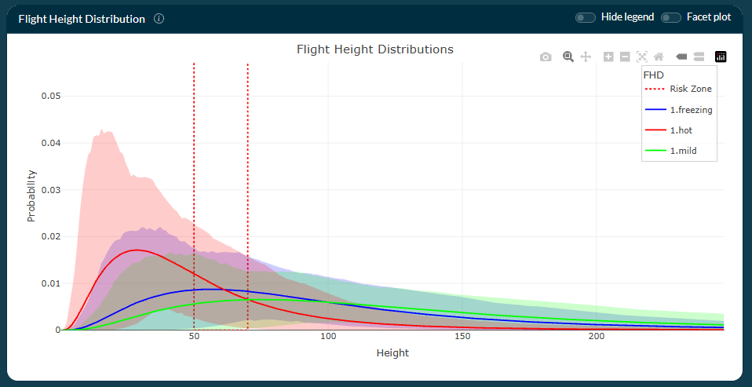

- Hover over any point to see the underlying values.
- **Hide legend** clears the legend when comparing many curves.
- **Facet plot** splits the distributions into one panel each, instead of overlaying them. Overlay is better for judging where curves differ; facets are better once you have more than three or four, or when the curves sit on very different scales.
- Where a covariate is switched on, legend entries are prefixed with the distribution’s number from the list — so `1.high` and `2.high` are the same covariate level from two different distributions.

### Summary tab

Reports, for each distribution, the percentage of flight time falling inside your rotor zone, at the 25th, 50th and 75th percentiles across the distribution’s draws.

Read these three figures together. The median alone tells you the central estimate; the spread between the 25th and 75th tells you how confident that estimate is. A distribution with a wide spread is telling you the underlying data is thin.

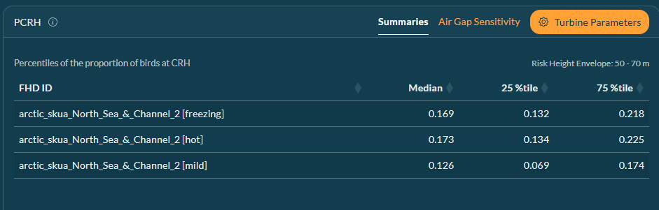

*Figure 11. The Summary tab.*

This is the mitigation view. It answers the question: *what happens if the air gap changes?*

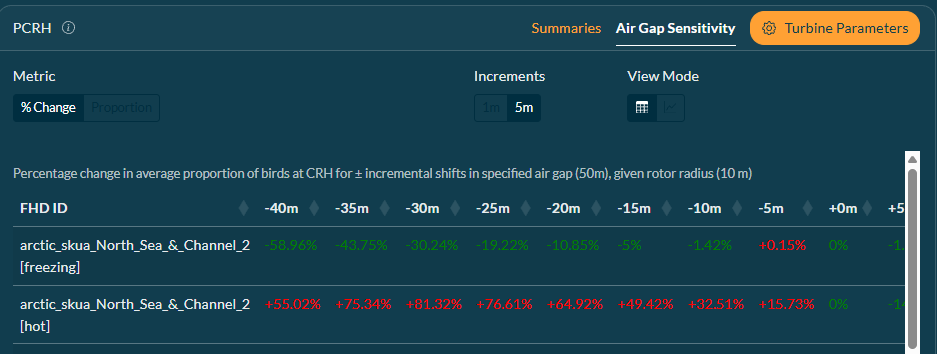

So a cell reading `-18.4%` in the `+5m` column means that raising the air gap by five metres reduces the proportion of flight time within the rotor zone by just over eighteen per cent, for that distribution.

> *Coming in the final release:* a plot of these values, and a comparison presentation capped at 40 m of air gap, as set out in the specification.

### Compare Distributions tab

> *Coming in the final release.* Comparison is currently done in the main distribution plot, which will display as many distributions as you select.

## Exporting your results

The **Download Options** panel prepares an export package for one distribution at a time. Choose the distribution from the drop-down, then press **Download**.

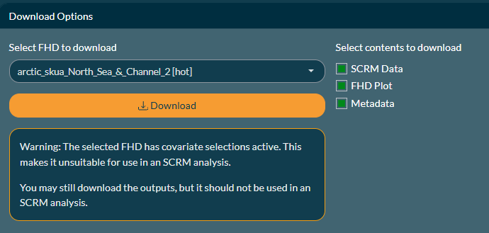

*Figure 13. The Download Options panel.*

The package is a ZIP archive named after the distribution, containing three files:

[output not shown]

Exporting reflects what is on screen: if you have covariates switched on, or have changed the rotor parameters, the exported data, metadata and plot all follow that configuration.

> **The plot image needs Chrome or Edge installed.** The PNG is produced by rendering the plot in a headless Chromium browser. If the app cannot find Chrome or Edge on your machine, it tells you so and still exports the data and metadata — you simply do not get the image.

If a distribution has covariates switched on, a warning appears beside these controls. Such outputs may be downloaded for reference but should not be used in sCRM.

> *Coming in the final release:* the three **Select contents to download** checkboxes are not yet applied — every export currently contains all three files regardless of what is ticked. The step that hands the finished package to your browser is also still being connected, so in this build the package is assembled but not yet offered for download.

## Saving and restoring a session

**Settings → Save Session** downloads a small `.rds` file recording where you were. **Settings → Restore Session** takes that file back and returns you to it.

> *Coming in the final release.* At present the saved file records only which screen you were on. The final version will restore your full selection, your covariate configuration and your turbine parameters, so a scenario can be put down and picked up later, or passed to a colleague.

## Messages and warnings

The application uses small pop-up messages rather than interrupting you. The ones you are most likely to see:

| Message | What it means | What to do |
| --- | --- | --- |
| **Too many datasets selected** | More than ten distributions are selected. | Deselect some. Only the first ten are analysed. |
| **Processing the selected FHDs failed for ‘…’** | A distribution could not be processed; the message names it. | Usually a covariate selection problem. Reset that distribution’s covariates. If it persists, report it. |
| **More than 10 unique FHDs were generated** | Covariate splitting has produced more than ten curves. | Reduce the covariate levels selected, or deselect a distribution. |

## Getting help and reporting problems

- **In the app** — the Help buttons on each panel, and **Start Tutorial** on the welcome screen.
- **Report a problem** — **Settings → Report a Bug** opens the issue tracker. Please include the version number from the navigation bar, what you selected, and what you expected to happen.
- **Project contacts** — listed under **Contacts** on the welcome screen.

## Glossary

[output not shown]

*Prepared by Black Bawks Data Science Ltd with DMP Statistical Solutions UK Ltd and NIRAS, for Natural England, as part of the ReSCUE project.*